# Assignment 3

STATS 220 Semester One 2022

Stephen Bay

2023-07-26

```css
@import url('https://fonts.googleapis.com/css2?family=Lato:ital,wght@0,400;0,700;1,400&display=swap');


body {font-family: 'Lato', sans-serif;
  text-align: justify;
  background: #D3F5E7;
  font-size: 18px
  }

h1, h2 {font-family: 'Lato', sans-serif;
  text-align: center;
  font-weight: 700;
  color: #DA1515;
  }

h3 {font-family: 'Lato', sans-serif;
  text-align: center;
  font-weight: 500;
  }

h4 {font-family: 'Lato', sans-serif;
  text-align: left;
  font-weight: 500;
  }

table {
  margin: auto;
  border: collapse;
  font-size: 15px;
  padding: 8px
}

thead, tfoot, tr:nth-child(even) { background: #CBEDDB; }

tr:hover {background-color: #A6C3B4;}

hr {border-color: #D3F5E7}

caption {
  caption-side: bottom;
  font-size: 15px;
  color: black;
  text-align: right;
}

blockquote {color: 'red';
border-color: #DA1515}
```

## Data Tables and Creating New Variables

For this Assignment, I have decided to extract data from the Google Books API and `boardgamegeek.com` with titles containing the word *“Monopoly”*.

> Monopoly *(noun)*: the exclusive possession or control of the supply of or trade in a commodity or service.

> Google

When extracting data from `boardgamegeek.com`, I expect to find a range of different versions of the trademarked game *Monopoly*. On the other hand, when it comes to sourcing books containing the same word, there may be a large variety of content such as marketing and business strategies, politics, or perhaps books against consumerism and mega-corporations; There may even be books talking about the board game itself.

## Book data

### Sourcing data from the Google Books API

```r
#query searching for word "monopoly" in book title

query <- "https://www.googleapis.com/books/v1/volumes?q=intitle:%22monopoly%22&startIndex=0&maxResults=40"

response <- fromJSON(query, flatten = TRUE)

book_data <- response$items

#two variables from extracted data
title_and_pub_date = book_data %>%
  select(volumeInfo.title, volumeInfo.publishedDate)

my_col_names = c('Book Title', 'Publishing Date')

knitr::kable(title_and_pub_date, col.names = my_col_names, align = 'l', caption = "Table 1")
```

Table 1

| Book Title | Publishing Date |
| --- | --- |
| Bossism and Monopoly | 1906 |
| The Rubber Industry, a Study in Competition and Monopoly | 1948 |
| Industrial Germany | 2013-09-12 |
| Monopoly and Cartels: April 23, 29, May 23, July 16, and 17, 1952 | 1952 |
| Competitive problems in the drug industry | 1967 |
| Advertising of proprietary medicines | 1971 |
| Beauties of the Monopoly System of New Jersey | 1848 |
| Laws and Regulations Relating to the Government Monopoly of Japan | 1906 |
| Study of Monopoly Power | 1951 |
| Competitive Problems in the Drug Industry | 1976 |
| Between Monopoly and Free Trade | 2016-09-13 |
| Monopoly | 2004 |
| Manufacturing Consent | 2012-10-15 |
| Plutocracy | 2020-12-15 |
| Beyond Monopoly Capitalism and Monopoly Socialism | 1978 |
| Monopoly on Wheels | 2011 |
| Labor and Monopoly Capital | 1998-12 |
| Is Government the Source of Monopoly? and Other Essays | 1980 |
| Problems of Monopoly and Economic Warfare | 2018-01-12 |
| The New Deal and the Problem of Monopoly | 1974 |
| Monopoly and Competition and Their Regulation | 1954 |
| British Broadcasting | 2013-11-26 |
| The Tobacco Monopoly in the Philippines | 1980 |
| The End of the Communist Power Monopoly | 1993 |
| The Theory of Monopoly Capitalism | 2014-04 |
| Monopoly | 2007-10-09 |
| Against Intellectual Monopoly | 2008-07-07 |
| The End of a Natural Monopoly | 2003-07-17 |
| Monopoly Capital | 1966 |
| The Regulation of Monopoly | 1989-03-31 |
| Monopoly and Restrictive Practices | 2013-11-05 |
| Monopoly Mail | 2017-09-29 |
| Agrarian Justice Opposed to Agrarian Law, and to Agrarian Monopoly; Being a Plan for Meliorating the Condition of Man, by Creating in Every Nation a National Fund, Etc | 1817 |
| Agrarian Justice opposed to Agrarian Law, and to Agrarian Monopoly, etc | 1797 |
| The Monopoly of Man | 2021-04-06 |
| Agrarian Justice, Opposed to Agrarian Law, and to Agrarian Monopoly | 1819 |
| Pass Go and Collect $200 | 2018-07-17 |
| Salt and State | 2020-08 |
| Bargaining and Group Decision Making | 1977 |
| Monopoly, Money, and You: How to Profit from the Game’s Secrets of Success | 2013-03-29 |

### Creating a new data frame

```r
#six selected and renamed variables
mini_data = book_data %>%
  rename(book_title = volumeInfo.title,
           page_count = volumeInfo.pageCount,
           published_date = volumeInfo.publishedDate,
           publisher = volumeInfo.publisher,
           category = volumeInfo.categories,
           listing_price = saleInfo.listPrice.amount) %>%
  select(book_title, page_count, published_date, publisher, category, listing_price) %>%
  arrange(page_count)

my_col_names_2 = c('Book Title', 'Page Count', 'Publishing Date', 'Publisher', 'Category', 'Listing Price')

knitr::kable(mini_data, col.names = my_col_names_2, align = 'l', caption = "Table 2")
```

Table 2

| Book Title | Page Count | Publishing Date | Publisher | Category | Listing Price |
| --- | --- | --- | --- | --- | --- |
| Agrarian Justice Opposed to Agrarian Law, and to Agrarian Monopoly; Being a Plan for Meliorating the Condition of Man, by Creating in Every Nation a National Fund, Etc | 18 | 1817 | NA | NULL | NA |
| Agrarian Justice opposed to Agrarian Law, and to Agrarian Monopoly, etc | 24 | 1797 | NA | NULL | NA |
| Agrarian Justice, Opposed to Agrarian Law, and to Agrarian Monopoly | 32 | 1819 | NA | Agriculture | NA |
| Pass Go and Collect $200 | 40 | 2018-07-17 | Henry Holt and Company (BYR) | Juvenile Nonfiction | 24.61 |
| Is Government the Source of Monopoly? and Other Essays | 88 | 1980 | NA | Industrial Concentration | NA |
| Monopoly | 104 | 2004 | Gibbs Smith | Atlantic City (N.J.) | NA |
| Beyond Monopoly Capitalism and Monopoly Socialism | 107 | 1978 | Transaction Publishers | Capitalism | NA |
| The Monopoly of Man | 112 | 2021-04-06 | MIT Press | Social Science | 31.39 |
| Laws and Regulations Relating to the Government Monopoly of Japan | 120 | 1906 | NA | Camphor industry and trade | NA |
| Beauties of the Monopoly System of New Jersey | 138 | 1848 | NA | Monopolies | NA |
| Plutocracy | 144 | 2020-12-15 | NBM | Comics & Graphic Novels | 31.51 |
| British Broadcasting | 152 | 2013-11-26 | Routledge | History | NA |
| Bargaining and Group Decision Making | 152 | 1977 | Greenwood-Heinemann Publishing | Decision making | NA |
| Problems of Monopoly and Economic Warfare | 166 | 2018-01-12 | Routledge | Business & Economics | 76.08 |
| Monopoly and Cartels: April 23, 29, May 23, July 16, and 17, 1952 | 168 | 1952 | NA | Cartels | NA |
| Monopoly and Restrictive Practices | 184 | 2013-11-05 | Routledge | Business & Economics | 102.23 |
| Monopoly Mail | 210 | 2017-09-29 | Routledge | Business & Economics | NA |
| The Tobacco Monopoly in the Philippines | 248 | 1980 | Ateneo University Press | Monopolies | NA |
| The End of a Natural Monopoly | 258 | 2003-07-17 | Routledge | Business & Economics | 123.64 |
| Industrial Germany | 259 | 2013-09-12 | Cambridge University Press | Business & Economics | NA |
| Between Monopoly and Free Trade | 268 | 2016-09-13 | Princeton University Press | Business & Economics | NA |
| Manufacturing Consent | 286 | 2012-10-15 | University of Chicago Press | Social Science | 62.96 |
| Monopoly, Money, and You: How to Profit from the Game’s Secrets of Success | 288 | 2013-03-29 | McGraw Hill Professional | Business & Economics | 50.01 |
| The End of the Communist Power Monopoly | 306 | 1993 | Manchester University Press | Communism | NA |
| Against Intellectual Monopoly | 312 | 2008-07-07 | Cambridge University Press | Business & Economics | NA |
| Monopoly | 313 | 2007-10-09 | Da Capo Press | Social Science | NA |
| The Theory of Monopoly Capitalism | 320 | 2014-04 | NYU Press | Business & Economics | NA |
| The Regulation of Monopoly | 332 | 1989-03-31 | Cambridge University Press | Business & Economics | NA |
| Monopoly on Wheels | 334 | 2011 | Wayne State University Press | Automobile industry and trade | NA |
| Advertising of proprietary medicines | 340 | 1971 | NA | Advertising | NA |
| Competitive problems in the drug industry | 360 | 1967 | NA | Pharmaceutical industry | NA |
| Labor and Monopoly Capital | 372 | 1998-12 | NYU Press | Business & Economics | NA |
| Bossism and Monopoly | 388 | 1906 | NA | Bossism | NA |
| Salt and State | 411 | 2020-08 | U of M Center for Chinese Studies | NULL | NA |
| Monopoly Capital | 415 | 1966 | NYU Press | Political Science | NA |
| The Rubber Industry, a Study in Competition and Monopoly | 428 | 1948 | NA | Rubber industry and trade | NA |
| The New Deal and the Problem of Monopoly | 525 | 1974 | NA | NULL | NA |
| Monopoly and Competition and Their Regulation | 576 | 1954 | London : Macmillan | Competition | NA |
| Study of Monopoly Power | 1216 | 1951 | NA | Trusts, Industrial | NA |
| Competitive Problems in the Drug Industry | 1486 | 1976 | NA | Competition, Unfair | NA |

### Mutating new variables

```r
#mutated data
mutated_data = mini_data %>%
  mutate(year_published = str_sub(published_date, 1, 4) %>%
           as.numeric(),

         game_related = ifelse(str_detect(str_to_lower(category), "game"),
                               "Yes", "No"),

         page_worth = round(page_count / listing_price, 2))

my_col_names_3 = append(my_col_names_2, c("Publishing Year", "Game Related", "Price per Page"))

knitr::kable(mutated_data, col.names = my_col_names_3, align = 'l', caption = "Table 3")
```

Table 3

| Book Title | Page Count | Publishing Date | Publisher | Category | Listing Price | Publishing Year | Game Related | Price per Page |
| --- | --- | --- | --- | --- | --- | --- | --- | --- |
| Agrarian Justice Opposed to Agrarian Law, and to Agrarian Monopoly; Being a Plan for Meliorating the Condition of Man, by Creating in Every Nation a National Fund, Etc | 18 | 1817 | NA | NULL | NA | 1817 | No | NA |
| Agrarian Justice opposed to Agrarian Law, and to Agrarian Monopoly, etc | 24 | 1797 | NA | NULL | NA | 1797 | No | NA |
| Agrarian Justice, Opposed to Agrarian Law, and to Agrarian Monopoly | 32 | 1819 | NA | Agriculture | NA | 1819 | No | NA |
| Pass Go and Collect $200 | 40 | 2018-07-17 | Henry Holt and Company (BYR) | Juvenile Nonfiction | 24.61 | 2018 | No | 1.63 |
| Is Government the Source of Monopoly? and Other Essays | 88 | 1980 | NA | Industrial Concentration | NA | 1980 | No | NA |
| Monopoly | 104 | 2004 | Gibbs Smith | Atlantic City (N.J.) | NA | 2004 | No | NA |
| Beyond Monopoly Capitalism and Monopoly Socialism | 107 | 1978 | Transaction Publishers | Capitalism | NA | 1978 | No | NA |
| The Monopoly of Man | 112 | 2021-04-06 | MIT Press | Social Science | 31.39 | 2021 | No | 3.57 |
| Laws and Regulations Relating to the Government Monopoly of Japan | 120 | 1906 | NA | Camphor industry and trade | NA | 1906 | No | NA |
| Beauties of the Monopoly System of New Jersey | 138 | 1848 | NA | Monopolies | NA | 1848 | No | NA |
| Plutocracy | 144 | 2020-12-15 | NBM | Comics & Graphic Novels | 31.51 | 2020 | No | 4.57 |
| British Broadcasting | 152 | 2013-11-26 | Routledge | History | NA | 2013 | No | NA |
| Bargaining and Group Decision Making | 152 | 1977 | Greenwood-Heinemann Publishing | Decision making | NA | 1977 | No | NA |
| Problems of Monopoly and Economic Warfare | 166 | 2018-01-12 | Routledge | Business & Economics | 76.08 | 2018 | No | 2.18 |
| Monopoly and Cartels: April 23, 29, May 23, July 16, and 17, 1952 | 168 | 1952 | NA | Cartels | NA | 1952 | No | NA |
| Monopoly and Restrictive Practices | 184 | 2013-11-05 | Routledge | Business & Economics | 102.23 | 2013 | No | 1.80 |
| Monopoly Mail | 210 | 2017-09-29 | Routledge | Business & Economics | NA | 2017 | No | NA |
| The Tobacco Monopoly in the Philippines | 248 | 1980 | Ateneo University Press | Monopolies | NA | 1980 | No | NA |
| The End of a Natural Monopoly | 258 | 2003-07-17 | Routledge | Business & Economics | 123.64 | 2003 | No | 2.09 |
| Industrial Germany | 259 | 2013-09-12 | Cambridge University Press | Business & Economics | NA | 2013 | No | NA |
| Between Monopoly and Free Trade | 268 | 2016-09-13 | Princeton University Press | Business & Economics | NA | 2016 | No | NA |
| Manufacturing Consent | 286 | 2012-10-15 | University of Chicago Press | Social Science | 62.96 | 2012 | No | 4.54 |
| Monopoly, Money, and You: How to Profit from the Game’s Secrets of Success | 288 | 2013-03-29 | McGraw Hill Professional | Business & Economics | 50.01 | 2013 | No | 5.76 |
| The End of the Communist Power Monopoly | 306 | 1993 | Manchester University Press | Communism | NA | 1993 | No | NA |
| Against Intellectual Monopoly | 312 | 2008-07-07 | Cambridge University Press | Business & Economics | NA | 2008 | No | NA |
| Monopoly | 313 | 2007-10-09 | Da Capo Press | Social Science | NA | 2007 | No | NA |
| The Theory of Monopoly Capitalism | 320 | 2014-04 | NYU Press | Business & Economics | NA | 2014 | No | NA |
| The Regulation of Monopoly | 332 | 1989-03-31 | Cambridge University Press | Business & Economics | NA | 1989 | No | NA |
| Monopoly on Wheels | 334 | 2011 | Wayne State University Press | Automobile industry and trade | NA | 2011 | No | NA |
| Advertising of proprietary medicines | 340 | 1971 | NA | Advertising | NA | 1971 | No | NA |
| Competitive problems in the drug industry | 360 | 1967 | NA | Pharmaceutical industry | NA | 1967 | No | NA |
| Labor and Monopoly Capital | 372 | 1998-12 | NYU Press | Business & Economics | NA | 1998 | No | NA |
| Bossism and Monopoly | 388 | 1906 | NA | Bossism | NA | 1906 | No | NA |
| Salt and State | 411 | 2020-08 | U of M Center for Chinese Studies | NULL | NA | 2020 | No | NA |
| Monopoly Capital | 415 | 1966 | NYU Press | Political Science | NA | 1966 | No | NA |
| The Rubber Industry, a Study in Competition and Monopoly | 428 | 1948 | NA | Rubber industry and trade | NA | 1948 | No | NA |
| The New Deal and the Problem of Monopoly | 525 | 1974 | NA | NULL | NA | 1974 | No | NA |
| Monopoly and Competition and Their Regulation | 576 | 1954 | London : Macmillan | Competition | NA | 1954 | No | NA |
| Study of Monopoly Power | 1216 | 1951 | NA | Trusts, Industrial | NA | 1951 | No | NA |
| Competitive Problems in the Drug Industry | 1486 | 1976 | NA | Competition, Unfair | NA | 1976 | No | NA |

### Summary

```r
#group by whether they are related to game category or not
#show number of books in group and mean number of pages


summarised_data = mutated_data %>%
  group_by(game_related) %>%
  summarise(number_of_books = n(), mean_pages = round(mean(page_count, na.rm = TRUE), 2))

my_col_names_4 = c("Game-Related", "Number of Books", "Mean Pages")
knitr::kable(summarised_data, col.names = my_col_names_4, align = 'c', caption = "Table 4")
```

Table 4

| Game-Related | Number of Books | Mean Pages |
| --- | --- | --- |
| No | 40 | 300 |

## Board game data

### First 25 fields of the boardgames table sourced from `boardgamegeek.sqlite`

```r
dbListFields(db_connection, "boardgames")[1:25]
```

```
##  [1] "row_names"                          "game.id"
##  [3] "game.type"                          "details.description"
##  [5] "details.image"                      "details.maxplayers"
##  [7] "details.maxplaytime"                "details.minage"
##  [9] "details.minplayers"                 "details.minplaytime"
## [11] "details.name"                       "details.playingtime"
## [13] "details.thumbnail"                  "details.yearpublished"
## [15] "attributes.boardgameartist"         "attributes.boardgamecategory"
## [17] "attributes.boardgamecompilation"    "attributes.boardgamedesigner"
## [19] "attributes.boardgameexpansion"      "attributes.boardgamefamily"
## [21] "attributes.boardgameimplementation" "attributes.boardgameintegration"
## [23] "attributes.boardgamemechanic"       "attributes.boardgamepublisher"
## [25] "attributes.total"
```

### My SQL query

```sql
-- selected 4 variables and renamed them
-- created new variable, years_since_published
-- looking for word match 'monopoly'
-- custom filter to remove NA values from category and playing_time
-- limit to first 40 values

SELECT
  `details.name` AS name,
  `details.yearpublished` AS year_published,
  `details.playingtime` AS playing_time,
  `attributes.boardgamecategory` AS category,
  2022 - `details.yearpublished` AS years_since_published
  FROM boardgames
  WHERE `name` LIKE '%monopoly%'
  AND `playing_time` != 0
  AND LENGTH(`category`) > 2
  ORDER BY year_published DESC
  LIMIT 40
```

```r
#table containing sql-extracted data
my_col_names_5 = c("Name", "Publishing Year", "Average Play Time",
                   "Game Category", "Years Since Published")
knitr::kable(board_game_data, col.names = my_col_names_5, align = 'l', caption = "Table 5")
```

Table 5

| Name | Publishing Year | Average Play Time | Game Category | Years Since Published |
| --- | --- | --- | --- | --- |
| Monopoly Jackpot | 2016 | 180 | Economic | 6 |
| Monopoly: World Football Stars | 2016 | 180 | Economic,Negotiation,Sports | 6 |
| Monopoly: Ghostbusters edition | 2016 | 90 | Economic,Movies / TV / Radio theme,Negotiation | 6 |
| Monopoly: Ultimate Banking | 2016 | 60 | Economic | 6 |
| Monopoly: Rot-Weiss Essen | 2015 | 150 | Economic,Negotiation | 7 |
| Monopoly: Kinder Überraschung | 2015 | 150 | Economic,Negotiation | 7 |
| Monopoly: Werder Bremen | 2015 | 150 | Economic,Negotiation | 7 |
| Monopoly: Zwickau | 2015 | 150 | Economic,Negotiation | 7 |
| Monopoly: Firefly | 2015 | 150 | Economic,Fantasy,Movies / TV / Radio theme,Negotiation,Science Fiction | 7 |
| Monopoly: Marvel Avengers | 2015 | 90 | Economic | 7 |
| Monopoly: Aruba | 2015 | 120 | Economic,Negotiation | 7 |
| Monopoly: Apeldoorn | 2015 | 120 | Economic,Negotiation | 7 |
| Monopoly: OE Offshore Engineer | 2015 | 120 | Economic,Industry / Manufacturing,Negotiation | 7 |
| Monopoly: Star Wars | 2015 | 60 | Economic,Science Fiction | 7 |
| Christmas Monopoly Limited Edition | 2015 | 180 | Economic,Negotiation | 7 |
| Monopoly: Halo Collector’s Edition | 2015 | 240 | Economic,Negotiation,Science Fiction,Video Game Theme | 7 |
| KISS Rock Band Monopoly | 2015 | 180 | Economic,Music,Negotiation | 7 |
| Farewell Boleyn Monopoly | 2015 | 180 | Economic | 7 |
| Monopoly : Osaka Loop Line Edition | 2015 | 120 | Party Game | 7 |
| Monopoly: Wizard of Oz 75th Anniversary Collector’s Edition | 2014 | 100 | Dice,Economic,Movies / TV / Radio theme,Negotiation | 8 |
| Monopoly: FC Schalke 04 | 2014 | 100 | Dice,Economic,Negotiation,Sports | 8 |
| Monopoly: Fletcher Hotels | 2014 | 100 | Dice,Economic,Negotiation | 8 |
| Monopoly: WWE | 2014 | 100 | Dice,Economic,Negotiation | 8 |
| Monopoly: Brasilien | 2014 | 100 | Economic,Negotiation,Sports | 8 |
| Monopoly: Die Nationalmannschaft | 2014 | 100 | Economic,Fantasy,Negotiation | 8 |
| Monopoly: Curaçao | 2014 | 100 | Economic,Negotiation | 8 |
| England Football Stars Limited Edition Monopoly | 2014 | 60 | Dice,Economic,Negotiation,Sports | 8 |
| Monopoly: World Football Stars | 2014 | 100 | Economic,Negotiation | 8 |
| Monopoly: Nigerian Centenary Edition | 2014 | 100 | Economic,Negotiation | 8 |
| My Monopoly | 2014 | 180 | Economic,Negotiation | 8 |
| Monopoly Deal | 2014 | 15 | Card Game | 8 |
| Monopoly: The Big Bang Theory | 2014 | 120 | Economic,Humor,Movies / TV / Radio theme,Negotiation | 8 |
| Monopoly Junior: Disney Frozen | 2014 | 30 | Children’s Game | 8 |
| Monopoly: Assassin’s Creed | 2014 | 60 | Economic,Negotiation,Video Game Theme | 8 |
| Monopoly: Bottrop | 2014 | 150 | Economic,Negotiation | 8 |
| Monopoly: Glööckler | 2014 | 150 | Economic,Negotiation | 8 |
| Monopoly: Lippe | 2014 | 150 | Economic,Negotiation | 8 |
| Monopoly: LOSC Édition des Légendes | 2014 | 150 | Economic,Negotiation | 8 |
| Monopoly: A.S.S.E. Édition des légendes | 2014 | 150 | Economic,Negotiation | 8 |
| Monopoly: Olympique Lyonnais | 2014 | 150 | Economic,Negotiation | 8 |

## Personal Project

### Plotting a table to visualise the distribution of categories for the sampled Monopoly board game variety

In order to demonstrate a set of skills I have picked up from previous modules, I have decided to apply CSS to format my HTML document into a *‘Monopoly theme’* and to create a plot using `ggplot2`. I designed the following bar-plot to show the various categories our sample of monopoly games may cover, subset by the year they were published. I used tools and techniques such as the `seperate_rows()` and `mutate()` functions as well as self-taught methods to editing a plot using `ggplot2` to demonstrate knowledge I have gained from our previous topics.

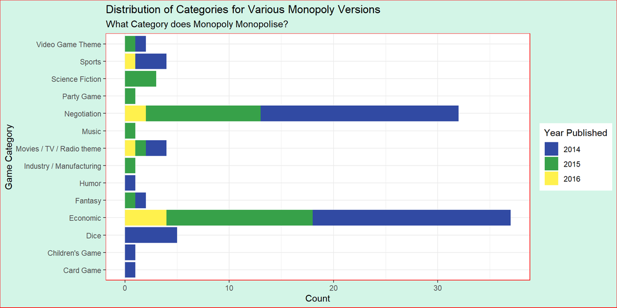

```r
#plot to show distribution of categories the sampled monopoly games fall under
board_game_data %>%
  mutate(year_category = as.factor(year_published)) %>%
  separate_rows(category, sep = ",") %>%
  ggplot() +
  geom_bar(aes(y = category, fill = year_category)) +
  labs(title = "Distribution of Categories for Various Monopoly Versions",
       subtitle = "What Category does Monopoly Monopolise?",
       y = "Game Category",
       x = "Count",
       fill = 'Year Published') +
  scale_fill_manual(values = c('2014' = "#314AA3",
                               '2015' = "#37A149",
                               '2016' = "#FFF14D")) +
  theme_bw() +
  theme(plot.background = element_rect(fill = "#D3F5E7", colour = "red"),
        panel.border = element_rect(colour = "red"))
```

## Learning reflection

In this module I was able to learn about various forms data can be stored in, and how to extract and filter the information from its content. This will be extremely helpful for me in the future as I progress in the field of data science, since I will need to be able to efficiently extract and analyse big data. I would really like to learn more about SQL and its applications, since what we have been taught on the topic seemed very specific for the assignment and I don’t feel confident using it independently. I would also like to learn more about RStudio and forming connections to other consoles such as Python or MySQL.